# STATS 780 Written Report for Final Project

Amandeep Sidhu (400076920)

17 January, 2023

## Introduction

In this final project, the data set selected for our analysis was titled healthcare-dataset-stroke-data.csv and can be obtained from the kaggle website (Fedesoriano 2020). The data set includes healthcare information for stroke detection using the predictor variables recorded (e.g. gender, bmi, smoking_status). For literature review, this data set has not been used in any formal papers (according to the information on the kaggle website), but other kaggle contributors have attempted to produce effective models using this data. Models previously produced incorporated the use of supervised learning (i.e. classification techniques) involving boosting and SVM. According to the World Health Organization (WHO), stroke rank among the global leaders in causes of death (WHO 2020). As a result, models that can efficiently predict the likeliness of a patient to have a stroke is crucial for medical practitioners. With this in mind, the problem at hand is to develop a model that can classify whether a patient is likely to get a stroke or not based on predictor variables provided by healthcare facilities. For example, a previous approach implemented by Ustundag (2022) describes the use of a boosting algorithm to classify which patients were likely to get a stroke based on the predictors available in the data set. Conversely, another approach that Adamidis (2022) implemented, incorporates support vector machine (SVM) to classify patients into the appropriate categories. In this project, we will implement our two model approaches and compare the results accordingly.

Observing the data set entries, we see that the response variable is a binary categorical variable. The variable is called “stroke” and its values are only 0 or 1. As a result, it makes sense to implement classification methods to determine which patients are likely to get a stroke (i.e. this is a classification statistical problem) using theory discussed in lecture. Recall in literature that classification is a form of supervised machine learning that can classify observations into groups based on multiple features (or attributes). In particular, classification models essentially read some inputs and generates an output that classifies the input into a category that seems reasonable. For the purpose of this project, we will be classifying whether patients are likely to get a stroke or not, depending on the various predictors recorded in the data set by medical practitioners.

## Methods

For both approaches, the feature engineering and variable selection for this data set includes removing the id (patient id) variable away from the data set as it was found to have little to no effect on classifying the response variable. In addition to this approach, dummy variables were created for the categorical variables as the original values for these variables were not readable by the algorithm. For example, if we observe the gender variable that has values of Male, Female and Other, we code a dummy variable for each value as 1, 0 and 2 respectively. See the coding section for this process.

### Method 1: Random Forests Algorithm

The first method that we will implement on the data set is called the Random Forests algorithm. In essence, this algorithm is an ensemble classification approach whose aim is to construct a collection of decision trees with controlled variation (Fawahgreh, Gaber, and Elyan 2013). It is also important to note that because the random forest approach is made up of multiple decision trees, it may be considered computationally expensive. Because of the computation complexity of decision trees, the random forests algorithm was originally developed to address this limitation by entertaining a small number of predictors available at each node (or split). This will be called “m” during the coding procedure. Thus, two important hyper-parameters will need to be tuned during the creation of the model: the number of predictors available at each split (i.e. m) and the number of trees (i.e. ntrees). The result of this procedure is to potentially improve model performance of the data set. In order to tune these parameters, we can use the Random Forests package in R as we can simulate a random forest model across various values of “m” and “ntrees” and see which values yield the best results (Breiman et al. 2022). Then, the values that have the best results will be used in the final random forest model for analysis. As previously mentioned, the computational complexity is vital to evaluating model performance as a less computationally expensive model may be preferred over one that is relatively expensive. For the random forests approach, the computational complexity is O(n*log(n)*d*k) (Kumar 2019). This will be compared with out second approach to evaluate efficiency. Finally, in order to guarantee reproducibility of results, we will initiate a seed to ensure that values are consistent for each trial.

### Method 2: Weighted K-NN Classifier

The second approach that we will implement (and was not discussed in lecture) is the weighted K-NN machine learning algorithm. This algorithm incorporates a similar approach to the K-NN algorithm but attempts to address potential issues with respect to the choosing of the hyper-parameter k. Recall that K is the number of nearest neighbours the model will consider for analysis. IN literature, values of K may influence the results of the model depending on whether K is too small or too big. If the value of K is too small, we may yield results with higher variance and lower bias. This would be a problem as the model may be more sensitive to data points that are considered outliers. If the value of K is too large, we would yield results with lower variance and a higher bias. This would also be a problem as a neighbourhood may pull in points that belong to another neighbourhood and mis-classify points. The solution that the Weighted K-NN approach provides is by creating and assigning weights to points. In a practical sense, a heavier weight is assigned to points that are nearby one another, and a smaller weight to points further away (Zhao and Chen 2015). Using a mathematical explanation, the inverse distance function is used, which implies that as the distance increases, the weight decreases (and vice versa). Furthermore, as Zhao and Chen (2015) explains, the weights are learned using both of gradient descent and cross-validation. The only important tuning parameter for this approach is the parameter K, which denotes the number of neighbourhoods. This can be done with the help of evaluating various error rates for different K values. The K value that yields the lowest error rate will be selected and implemented in the final version of the Weighted K-NN model. The computational cost for this method is O(knd), which is similar to the K-NN algorithm (Kumar 2019). Thus, it is suitable to use the Weighted K-NN approach instead of the K-NN as it addresses potential limitations of the K-NN model and maintains its computational cost. Once, again, we implement a seed to guarantee the reproducibility of results.

### Description of Comparison Criterions

In order to compare and contrast the two model approaches that we will be implementing, we will use the confusion matrix and mis-classification rate on the test set to compare and contrast the Random Forests model versus the Weighted K-NN model. Recall that the confusion matrix is a N x N matrix that can be used for evaluating the performance of a classification model, where N is the number of target classes in the response variable (Bhandari 2020). Because we are attempting the compare the actual target values with the predicted ones by our classification models, it makes sense to use the confusion matrix as a possible comparison criterion to compare our models. The second comparison criterion that we will use is the mis-classification rate. Since, the mis-classification rate is a metric that tells us the fraction (as a percent) of the predictions that were wrong, it is also a logical choice to incorporate this metric to compare the performance of our classification models.

## Results

### Exploratory Data Analysis (EDA)

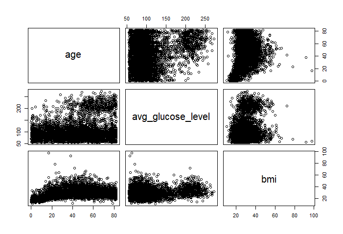

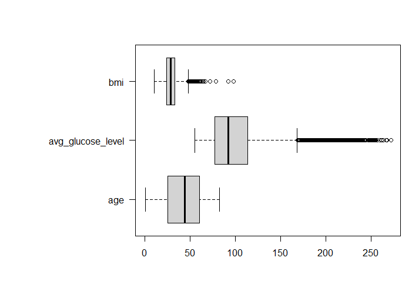

Observing Figure **4**, we see that there might be some concern with the average glucose level variable, but because the values are tightly compact at the ends we can leave this variable in for analysis. No statistical or data transformations were conducted on any of these variables present as the values are relatively close to one another.

### Results of Random Forests Algorithm

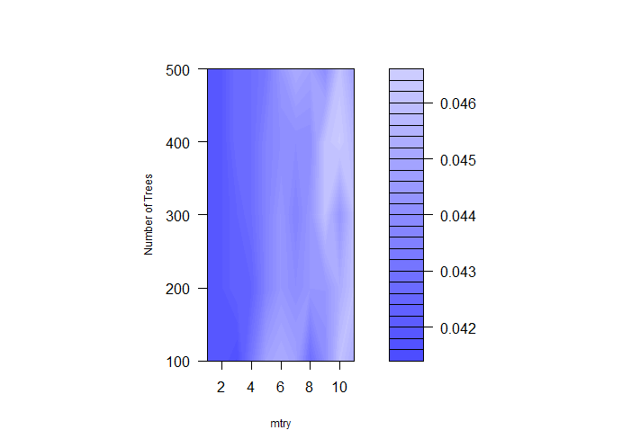

Now that the optimal tuning parameters have been found, we can evaluate how successful the model performs given our test data set that we originally split from the training data. We will investigate the performance using our first comparison criterion: confusion matrix.

|  | 0 | 1 |
| --- | --- | --- |
| 0 | 2347 | 2 |
| 1 | 106 | 0 |

### Results of Weighted K-NN Classifier

Once again, 50%-50% training-test split was conducted to evaluate the performance of the weighted K-NN classification method. The weighted K-NN model was obtained here by tuning the parameter, K, using the same technique to tune the parameter in a normal K-NN approach. In other words, the K with the lowest error rate was selected and implemented in the final model. Please see the code section to see how this was implemented.

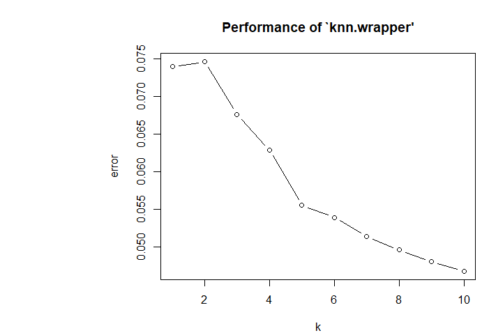

Observing Figure **6**, we can see that the error rate is lowest at 10 but begins to tail off at around K = 7 neighbourhoods. We select K = 7 as our tuning parameter value because the changes in error rate past this value are minimal enough to not notice a big difference. Now let us observe the confusion matrix of the Weighted K-NN algorithm and calculate the mis-classification rate from this table. Recall that the mis-classification rate is a metric that tells us the fraction (as a percent) of the predictions that were wrong (and accuracy is the proportion of right predictions in contrast to this).

|  | 0 | 1 |
| --- | --- | --- |
| 0 | 2334 | 17 |
| 1 | 101 | 2 |

Table **2** appears to do a good job classifying patients with entries of 0 but a poor job with patients with entries of 1 (i.e. likely to get a stroke). Moreover, from this Table we can compute the mis-classification rate and accuracy which are 0.04808476 (or 4.8%) and 0.95191524 (or 95.2%) respectively. In the conclusion section, we will compare the results and discuss why the confusion matrix may be poor in terms of classifying patients with ‘1’ entries in the response variable column.

If we interpret the results of applying both methods in the context of the original data set, both methods do a great job in classifying patients whom are not at risk of getting a stroke, but fail to do a good job at classifying patients who are at risk (i.e. ‘1’ observations in the data). Though the accuracy is high for both algorithms, it is heavily skewed as there are more patients with ‘0’ observations.

## Conclusion

To observe the differences in results of the mis-classification rates of different techniques implemented, observe Table **3**.

[output not shown]

### Findings in the Context of the Data and Problem

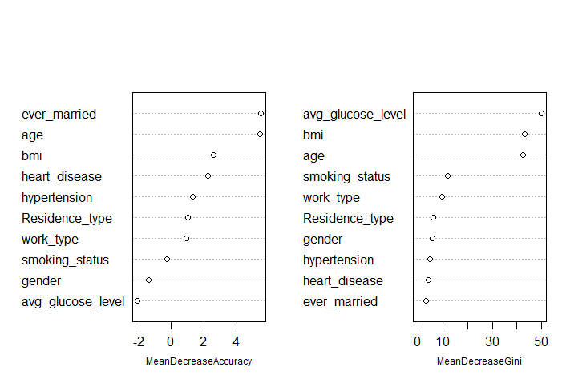

## References

Adamidis, Avraam. 2022. *Stroke Prediction EDA + ML Newbie Edition*. https://www.kaggle.com/code/abraamadamidis/stroke-prediction-eda-ml-newbie-edition.

Bhandari, Aniruddha. 2020. *Everything You Should Know about Confusion Matrix for Machine Learning*. https://www.analyticsvidhya.com/blog/2020/04/confusion-matrix-machine-learning/#:~:text=A%20Confusion%20matrix%20is%20an,by%20the%20machine%20learning%20model.

Breiman, Leo, Adele Cutler, Andy Liaw, and Matthew Wiener. 2022. *randomForest: Breiman and Cutler’s Random Forests for Classification and Regression*. https://cran.r-project.org/web/packages/randomForest/index.html.

Fawahgreh, Khaled, Mohamed Medhat. Gaber, and Eyad Elyan. 2013. “Random Forests: From Early Developments to Recent Advancements.”

Fedesoriano. 2020. *Stroke Prediction Dataset*. https://www.kaggle.com/datasets/fedesoriano/stroke-prediction-dataset.

Kumar, Paritosh. 2019. *Computational Complexity of ML Models*. https://medium.com/analytics-vidhya/time-complexity-of-ml-models-4ec39fad2770.

Ustundag, Emre. 2022. *Stroke Classification with Basic ML and Boosting*. https://www.kaggle.com/code/emreustundag/stroke-classification-with-basic-ml-and-boosting.

WHO. 2020. *The Top 10 Causes of Death*. https://www.who.int/news-room/fact-sheets/detail/the-top-10-causes-of-death.

Zhao, Ming, and Jingchao Chen. 2015. “Improvement and Comparison of Weighted k Nearest Neighbors Classifiers for Model Selection.”

## Supplementary Material

```r
library(dplyr)
library(e1071)
library(caret)
library(ggplot2)
library(randomForest)
library(kknn)

setwd("C:/Users/User/Documents/Stats_780_Final_Report")

df <- read.csv("healthcare-dataset-stroke-data.csv")
```

```r
#drop unnecessary columns

df <- df[c(2:12)]
head(df)
```

|  | gender | age | hypertension | heart_disease | ever_married | work_type | Residence_type | avg_glucose_level | bmi | smoking_status | stroke |
| --- | --- | --- | --- | --- | --- | --- | --- | --- | --- | --- | --- |
| 1 | Male | 67 | 0 | 1 | Yes | Private | Urban | 228.69 | 36.6 | formerly smoked | 1 |
| 2 | Female | 61 | 0 | 0 | Yes | Self-employed | Rural | 202.21 | N/A | never smoked | 1 |
| 3 | Male | 80 | 0 | 1 | Yes | Private | Rural | 105.92 | 32.5 | never smoked | 1 |
| 4 | Female | 49 | 0 | 0 | Yes | Private | Urban | 171.23 | 34.4 | smokes | 1 |
| 5 | Female | 79 | 1 | 0 | Yes | Self-employed | Rural | 174.12 | 24 | never smoked | 1 |
| 6 | Male | 81 | 0 | 0 | Yes | Private | Urban | 186.21 | 29 | formerly smoked | 1 |

**Figure 1:** First Six rows of the variables in the data set

```r
summary(df[c(1:3)])
```

```
##     gender               age         hypertension
##  Length:5110        Min.   : 0.08   Min.   :0.00000
##  Class :character   1st Qu.:25.00   1st Qu.:0.00000
##  Mode  :character   Median :45.00   Median :0.00000
##                     Mean   :43.23   Mean   :0.09746
##                     3rd Qu.:61.00   3rd Qu.:0.00000
##                     Max.   :82.00   Max.   :1.00000
```

**Figure 2:** Summary of First three variables in the data set

```r
#assign dummy variables to the appropriate columns here

#fix gender variable (1 represents male and 0 represents female and 2 is other)
df[df == "Male"] <- 1
df[df == "Female"] <- 0
df[df == "Other"] <- 2

#fix ever_married to a numerical value
# (1 = yes, 0 = no)

df[df == "Yes"] <- 1
df[df == "No"] <- 0

#fix work_type variable
#(Private = 0, Self-employed = 1, children = 3, Govt_job = 2, Never_worked = 4)
df[df == "Private"] <- 0
df[df == "Self-employed"] <- 1
df[df == "Govt_job"] <- 2
df[df == "children"] <- 3
df[df == "Never_worked"] <- 4

#fix Residence_type variable

df[df == "Urban"] <- 0
df[df == "Rural"] <- 1

#fix smoking_status variable

df[df == "formerly smoked"] <- 0
df[df == "never smoked"] <- 1
df[df == "smokes"] <- 2
df[df == "Unknown"] <- 3


#drop bmi empty values (i.e. NaN)
df <- df[!(df$bmi == "NaN"|df$bmi == "N/A"),]

#convert to numerical values (useful for pairsplot)
df$bmi <- as.numeric(df$bmi)
df$gender <- as.numeric(df$gender)
df$ever_married <- as.numeric(df$ever_married)
df$work_type <- as.numeric(df$work_type)
df$Residence_type <- as.numeric(df$Residence_type)
df$smoking_status <- as.numeric(df$smoking_status)
```

```r
#Code for Pairsplot:

pairs(df[,c(2,8,9)])
```

```r
# Code for Boxplot:
par(mar=c(4,12,4,1))
boxplot(df[,c(2,8,9)], horizontal= TRUE, las= 1)
```

```r
# Implement the Random Forest Algorithm Here

#split the data
set.seed(1)
df$stroke <- factor(df$stroke)
train <- sample(1:nrow(df), nrow(df) / 2)
df.test <- df[-train, "stroke"]

#Algorithm 1: Random Forests
#let us first tune the parameters for this classifier
#begin by iterating throughout all predictor variables available

df_rf = tune.randomForest(stroke~., data = df[train,], mtry = 1:10,
                          ntree = 100*1:5,
                          tunecontrol = tune.control(sampling = "cross",
                                                     cross = 5))
#summary(df_rf)
plot(df_rf, main = "", xlab = "mtry", ylab="Number of Trees", cex.lab = 0.75,
     cex.axis= 1)

#the optimal m and ntrees were found to be 3 and 100 respectively

set.seed(1)
rf.df = randomForest(stroke~., data = df, subset = train, mtry = 3, ntree = 100,
                     importance = TRUE)

#avg_glucose, age, id, bmi most important

rf_pred <- predict(rf.df, df[-train,], type ="class")

#classification table

tab1 <- table(df.test, rf_pred)
tab1

#mis-classification rate
1-classAgreement(tab)$diag

#value of about 0.0436 or 4.36%!
```

```r
#Algorithm 2: Weighted K-NN ML

set.seed(1)
df$stroke <- factor(df$stroke)
train <- sample(1:nrow(df), nrow(df) / 2)
df.learn <- df[-train,]
df.valid <- df[train,]

#find optimal k neighbours

obj2 <- tune.knn(df.learn, df.learn$stroke, k = 1:10,
                 tunecontrol = tune.control(sampling = "boot"))
#summary(obj2)
#plot(obj2) - error rate plot

#we notice the error rate is lowest at k = 7

#apply weighted kknn

df.kknn <- kknn(stroke~., df.learn, df.valid, k = 7, distance = 1,
                kernel = "triangular")
fit <- fitted(df.kknn)
tab2 <- table(df.valid$stroke, fit)

#mis-classification rate
1-classAgreement(tab2)$diag

#error rate is 0.04808476 or 4.80% - nice
```

```r
# variable importance plot code
varImpPlot(rf.df, main ="", cex.lab = 0.75)
```